# Data Summary in R

Sheherazade (R ladies Bogor)

02/07/2019

# Before!

- Always check which project and working directory you are working now

```r
getwd()
```

```
## [1] "/Volumes/Sheherazade/syllabus/syllabus"
```

- All the dataset is in the folder used as a working directory
- All the materials are compiled from different sources:
  - McGarigal, K. Course Analysis of Environmental Data: Introduction to R. University of Massachusetts Amherst. www.umass.edu/landeco/teaching/ecodata/syllabus.ecodata.pdf
  - www.statisticssolutions.com/data-levels-of-measurement/
  - www.statmethods.net/stats/descriptives.html
  - www.r-bloggers.com/r-tutorial-series-summary-and-descriptive-statistics/
  - www.sthda.com/english/wiki/descriptive-statistics-and-graphics

# Data Summary in R

Variables -> named computer memory. For example, a list of species recorded stored in variable named ‘species_name’.

```r
pi <- 3.14 #real
number_species <- 327 #integer
species_name <- 'Panthera tigris' #character/string, should be entered in quotes
rainforest <- TRUE #logical (only TRUE or FALSE)
```

## Data Structures

1. **vectors** : one-dimensional, a single data type (*e.g.* integer, real, and character/string).

```r
example_vector<-c(2,4,6,8,10)
example_vector
```

```
## [1]  2  4  6  8 10
```

```r
(example_vector<-c(2,4,6,8,10))
```

```
## [1]  2  4  6  8 10
```

```r
example_vector[2]     #individal item is identified by the sequence (1-n)
```

```
## [1] 4
```

2. **matrices** : two dimensional, created by binding two or more vectors of the same type and length.

```r
example_vector_2<-c(1,3,5,7,9)
example_matrix<-cbind(example_vector,example_vector_2)
example_matrix
```

```
##      example_vector example_vector_2
## [1,]              2                1
## [2,]              4                3
## [3,]              6                5
## [4,]              8                7
## [5,]             10                9
```

```r
example_matrix[4,2]   #row 4, column 2
```

```
## example_vector_2
##                7
```

```r
example_matrix[5,]    #row 5
```

```
##   example_vector example_vector_2
##               10                9
```

```r
example_matrix[,1]    #column 1
```

```
## [1]  2  4  6  8 10
```

```r
example_matrix[]      #all
```

```
##      example_vector example_vector_2
## [1,]              2                1
## [2,]              4                3
## [3,]              6                5
## [4,]              8                7
## [5,]             10                9
```

```r
example_matrix[,1:2]   #column 1 to 2
```

```
##      example_vector example_vector_2
## [1,]              2                1
## [2,]              4                3
## [3,]              6                5
## [4,]              8                7
## [5,]             10                9
```

```r
example_matrix[,-1]   #all except column 1. minus artinya kecuali
```

```
## [1] 1 3 5 7 9
```

3. **data frames** : one to multi-dimensional. Similar to spreadsheet. Column - field.

```r
data1<-read.csv("data1.csv")
head(data1)
```

```
##   name nationality gender      income age year_firstboyfriend height
## 1    a      german female lower_class  18                2010    189
## 2    b       china female lower_class  25                2011    154
## 3    c   indonesia female lower_class  32                2008    165
## 4    d       india female lower_class  22                2009    166
## 5    e    malaysia female lower_class  19                2010     16
## 6    f   indonesia female lower_class  26                2019    153
```

4. **lists** : compound objects of associated data. It could consist of vector, matrix, and data frames.

```r
example_list<-list(example_vector,data1)
example_list
```

```
## [[1]]
## [1]  2  4  6  8 10
##
## [[2]]
##    name nationality gender       income age year_firstboyfriend height
## 1     a      german female  lower_class  18                2010    189
## 2     b       china female  lower_class  25                2011    154
## 3     c   indonesia female  lower_class  32                2008    165
## 4     d       india female  lower_class  22                2009    166
## 5     e    malaysia female  lower_class  19                2010     16
## 6     f   indonesia female  lower_class  26                2019    153
## 7     g   indonesia female  lower_class  18                2017    167
## 8     h    malaysia female  lower_class  18                2011    170
## 9     i       china female  lower_class  18                2011    156
## 10    j      german female  lower_class  34                2019    175
```

[output cut: 20 more lines]

```r
names(example_list)<-c('vector','data frame')
example_list
```

```
## $vector
## [1]  2  4  6  8 10
##
## $`data frame`
##    name nationality gender       income age year_firstboyfriend height
## 1     a      german female  lower_class  18                2010    189
## 2     b       china female  lower_class  25                2011    154
## 3     c   indonesia female  lower_class  32                2008    165
## 4     d       india female  lower_class  22                2009    166
## 5     e    malaysia female  lower_class  19                2010     16
## 6     f   indonesia female  lower_class  26                2019    153
## 7     g   indonesia female  lower_class  18                2017    167
## 8     h    malaysia female  lower_class  18                2011    170
## 9     i       china female  lower_class  18                2011    156
## 10    j      german female  lower_class  34                2019    175
```

[output cut: 20 more lines]

## Data types

Understanding classification of data is a prerequisite for data summary and visualization, including to determine the correct statistical analysis. There are four levels of data measurement:

**1. Nominal data**  
Labels for a particular category, usually referred as categorical data. For example:

- Gender: male and female
- Religion: moslem, christian, hindu, budha, etc.
- Occupation: fisherman, businessman, etc.

In R, categorical data is represented as factors that contain levels.

You can check the structure of data using ‘str’ function.

```r
data1<-read.csv("data1.csv")
names(data1)
```

```
## [1] "name"                "nationality"         "gender"
## [4] "income"              "age"                 "year_firstboyfriend"
## [7] "height"
```

```r
str(data1$gender)
```

```
##  Factor w/ 2 levels "female","male": 1 1 1 1 1 1 1 1 1 1 ...
```

Gender is a factor, with two levels: male and female.

**2. Ordinal data**  
This is similar to nominal, but it has orders. For example:

- Level of income: lower class, middle class, and upper class
- Level of agreement: strongly disagree, disagree, neutral, agree, and strongly agree

In R, function `factor()` assigns order to nominal data.

```r
factor_income<-factor(data1$income,order=TRUE,levels=c("lower_class","middle_class","upper_class"))
str(factor_income)
```

```
##  Ord.factor w/ 3 levels "lower_class"<..: 1 1 1 1 1 1 1 1 1 1 ...
```

Nominal and ordinal data are also reffered to as qualitative data.

**3. Interval data**

- has values of equal intervals that mean something (20-30 C and 40-50 C have 10 degree differences)
- no absolute zero

For example: Temperature (Celcius, Fahrenheit)

**4. Ratio data**

- like interval data but has absolute zero

For example: height, weight (no 0 kg, but there is 0 C)

Interval and ratio data are usually called as quantitative data, which may be classified as **discrete** (integer in R) and **continuous** (real in R).

## Why is this important?

- t.test -> continuous data (sugar concentration in tomatoes)
- ANOVA -> continuous data (mice weight compared among control, treatment 1, and treatment 2)
- linear modelling -> determine distribution (binary categorical -> binomial, count discrete -> poisson)

**So, understand your data first!**

## Other basic operations in R

### Missing values

```r
example<-c(1,3,5,7,9,11)
#delete number 9 or replace it with NA (if delete 9 does not work) for this set of codes
example<-as.numeric(example)
str(example)
```

```
##  num [1:6] 1 3 5 7 9 11
```

```r
str(example)
```

```
##  num [1:6] 1 3 5 7 9 11
```

```r
is.na(example)     #to identify missing values
```

```
## [1] FALSE FALSE FALSE FALSE FALSE FALSE
```

```r
example_2<-example[!is.na(example)]  #to use all of the vector except the missing values
(example_2<-example[!is.na(example)]) #or
```

```
## [1]  1  3  5  7  9 11
```

```r
example_3<-na.omit(example)
example_3
```

```
## [1]  1  3  5  7  9 11
```

```r
(mean<-mean(example))
```

```
## [1] 6
```

```r
(mean_1<-mean(example,na.rm=TRUE))
```

```
## [1] 6
```

### Creating subsets

```r
head(data1)
```

```
##   name nationality gender      income age year_firstboyfriend height
## 1    a      german female lower_class  18                2010    189
## 2    b       china female lower_class  25                2011    154
## 3    c   indonesia female lower_class  32                2008    165
## 4    d       india female lower_class  22                2009    166
## 5    e    malaysia female lower_class  19                2010     16
## 6    f   indonesia female lower_class  26                2019    153
```

```r
data_new<-data1[,5:7]  #select all rows and columns 5 through 7
head(data_new)
```

```
##   age year_firstboyfriend height
## 1  18                2010    189
## 2  25                2011    154
## 3  32                2008    165
## 4  22                2009    166
## 5  19                2010     16
## 6  26                2019    153
```

```r
data_new<-data1[,-c(1:4)]
head(data_new)
```

```
##   age year_firstboyfriend height
## 1  18                2010    189
## 2  25                2011    154
## 3  32                2008    165
## 4  22                2009    166
## 5  19                2010     16
## 6  26                2019    153
```

```r
data_new<-data1[1:6,]   #select rows 1 through 6
head(data_new)
```

```
##   name nationality gender      income age year_firstboyfriend height
## 1    a      german female lower_class  18                2010    189
## 2    b       china female lower_class  25                2011    154
## 3    c   indonesia female lower_class  32                2008    165
## 4    d       india female lower_class  22                2009    166
## 5    e    malaysia female lower_class  19                2010     16
## 6    f   indonesia female lower_class  26                2019    153
```

```r
data_new<-subset(data1,nationality=="german")   #one of the most important functions
head(data1)
```

```
##   name nationality gender      income age year_firstboyfriend height
## 1    a      german female lower_class  18                2010    189
## 2    b       china female lower_class  25                2011    154
## 3    c   indonesia female lower_class  32                2008    165
## 4    d       india female lower_class  22                2009    166
## 5    e    malaysia female lower_class  19                2010     16
## 6    f   indonesia female lower_class  26                2019    153
```

```r
head(data_new)
```

```
##    name nationality gender       income age year_firstboyfriend height
## 1     a      german female  lower_class  18                2010    189
## 10    j      german female  lower_class  34                2019    175
## 11    k      german female middle_class  22                2016    180
```

```r
write.table(data_new,'german.csv',row.names = FALSE,sep=',')
write.table(data_new,'german2.csv',row.names = TRUE,sep=',')
```

### Packages in R

```r
library(tools)
library(HSAUR3)
data("USairpollution",package = "HSAUR3")
head(USairpollution)
```

```
##             SO2 temp manu popul wind precip predays
## Albany       46 47.6   44   116  8.8  33.36     135
## Albuquerque  11 56.8   46   244  8.9   7.77      58
## Atlanta      24 61.5  368   497  9.1  48.34     115
## Baltimore    47 55.0  625   905  9.6  41.31     111
## Buffalo      11 47.1  391   463 12.4  36.11     166
## Charleston   31 55.2   35    71  6.5  40.75     148
```

```r
str(USairpollution)
```

```
## 'data.frame':    41 obs. of  7 variables:
##  $ SO2    : int  46 11 24 47 11 31 110 23 65 26 ...
##  $ temp   : num  47.6 56.8 61.5 55 47.1 55.2 50.6 54 49.7 51.5 ...
##  $ manu   : int  44 46 368 625 391 35 3344 462 1007 266 ...
##  $ popul  : int  116 244 497 905 463 71 3369 453 751 540 ...
##  $ wind   : num  8.8 8.9 9.1 9.6 12.4 6.5 10.4 7.1 10.9 8.6 ...
##  $ precip : num  33.36 7.77 48.34 41.31 36.11 ...
##  $ predays: int  135 58 115 111 166 148 122 132 155 134 ...
```

Notes:

- HSAUR 3 is a functions, data sets, analyses and examples from the third edition of the book “A Handbook of Statistical Analyses Using R” (Torsten Horthorn and Brian S. Everitt, Chapman & Hall/CRC, 2014). [link](https://cran.r-project.org/web/packages/HSAUR3/index.html)
- USairpollution is the annual mean concentration of sulphur dioxide, in micrograms per cubic metre, is a measure of the air pollution of the city. This dataset is from packages `HSAUR3` [link](https://www.rdocumentation.org/packages/HSAUR3/versions/1.0-9/topics/USairpollution)

# Descriptive statistics

This is a summary statistic that describe and summarize our data. It is different to inferential statistic (e.g. testing hypothesis). Summary statistics:

- mean
- var -> a measure of variability, the greater the variability in the data, the greater will be our uncertaintiy in the values of parameter.
- min
- max
- median
- quantile

```r
head(USairpollution)
```

```
##             SO2 temp manu popul wind precip predays
## Albany       46 47.6   44   116  8.8  33.36     135
## Albuquerque  11 56.8   46   244  8.9   7.77      58
## Atlanta      24 61.5  368   497  9.1  48.34     115
## Baltimore    47 55.0  625   905  9.6  41.31     111
## Buffalo      11 47.1  391   463 12.4  36.11     166
## Charleston   31 55.2   35    71  6.5  40.75     148
```

```r
summary(USairpollution)
```

```
##       SO2              temp            manu            popul
##  Min.   :  8.00   Min.   :43.50   Min.   :  35.0   Min.   :  71.0
##  1st Qu.: 13.00   1st Qu.:50.60   1st Qu.: 181.0   1st Qu.: 299.0
##  Median : 26.00   Median :54.60   Median : 347.0   Median : 515.0
##  Mean   : 30.05   Mean   :55.76   Mean   : 463.1   Mean   : 608.6
##  3rd Qu.: 35.00   3rd Qu.:59.30   3rd Qu.: 462.0   3rd Qu.: 717.0
##  Max.   :110.00   Max.   :75.50   Max.   :3344.0   Max.   :3369.0
##       wind            precip         predays
##  Min.   : 6.000   Min.   : 7.05   Min.   : 36.0
##  1st Qu.: 8.700   1st Qu.:30.96   1st Qu.:103.0
##  Median : 9.300   Median :38.74   Median :115.0
##  Mean   : 9.444   Mean   :36.77   Mean   :113.9
##  3rd Qu.:10.600   3rd Qu.:43.11   3rd Qu.:128.0
##  Max.   :12.700   Max.   :59.80   Max.   :166.0
```

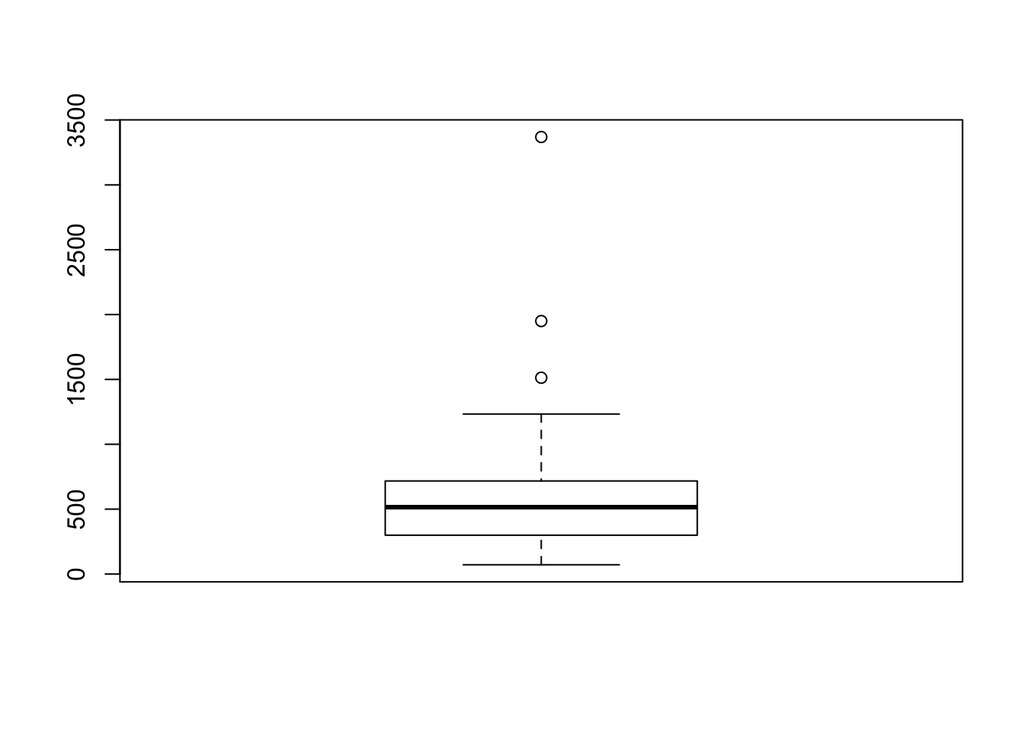

```r
boxplot(USairpollution$popul)
```

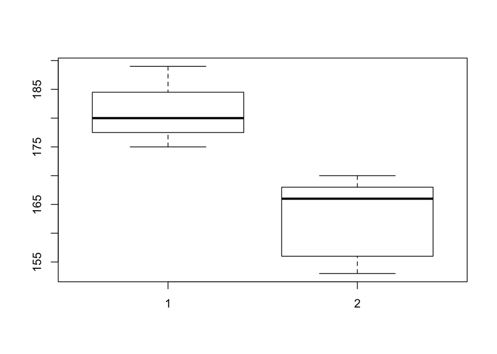

```r
data_german<-subset(data1,nationality=="german")
data_indonesia<-subset(data1,nationality=="indonesia")
boxplot(data_german$height,data_indonesia$height)
```

```r
sapply(USairpollution,mean,na.rm=TRUE)   #mean
```

```
##        SO2       temp       manu      popul       wind     precip
##  30.048780  55.763415 463.097561 608.609756   9.443902  36.769024
##    predays
## 113.902439
```

```r
sapply(USairpollution,sd,na.rm=TRUE)     #sd, different to se?
```

```
##        SO2       temp       manu      popul       wind     precip
##  23.472272   7.227716 563.473948 579.113023   1.428644  11.771550
##    predays
##  26.506419
```

```r
library(pastecs)
stat.desc(USairpollution)
```

```
##                       SO2         temp         manu        popul
## nbr.val        41.0000000   41.0000000     41.00000 4.100000e+01
## nbr.null        0.0000000    0.0000000      0.00000 0.000000e+00
## nbr.na          0.0000000    0.0000000      0.00000 0.000000e+00
## min             8.0000000   43.5000000     35.00000 7.100000e+01
## max           110.0000000   75.5000000   3344.00000 3.369000e+03
## range         102.0000000   32.0000000   3309.00000 3.298000e+03
## sum          1232.0000000 2286.3000000  18987.00000 2.495300e+04
## median         26.0000000   54.6000000    347.00000 5.150000e+02
## mean           30.0487805   55.7634146    463.09756 6.086098e+02
## SE.mean         3.6657530    1.1287796     87.99985 9.044226e+01
## CI.mean.0.95    7.4087633    2.2813487    177.85432 1.827906e+02
## var           550.9475610   52.2398780 317502.89024 3.353719e+05
## std.dev        23.4722722    7.2277160    563.47395 5.791130e+02
## coef.var        0.7811389    0.1296139      1.21675 9.515342e-01
##                     wind       precip      predays
## nbr.val       41.0000000   41.0000000   41.0000000
## nbr.null       0.0000000    0.0000000    0.0000000
## nbr.na         0.0000000    0.0000000    0.0000000
## min            6.0000000    7.0500000   36.0000000
## max           12.7000000   59.8000000  166.0000000
## range          6.7000000   52.7500000  130.0000000
## sum          387.2000000 1507.5300000 4670.0000000
## median         9.3000000   38.7400000  115.0000000
## mean           9.4439024   36.7690244  113.9024390
## SE.mean        0.2231167    1.8384072    4.1396072
## CI.mean.0.95   0.4509358    3.7155596    8.3664582
## var            2.0410244  138.5693840  702.5902439
## std.dev        1.4286442   11.7715498   26.5064189
## coef.var       0.1512769    0.3201485    0.2327116
```

```r
summary(data1)  #whcih type of data that allow for mean and sd calculation?
```

```
##       name        nationality    gender            income        age
##  a      : 1   australian:5    female:15   lower_class :10   Min.   :17.0
##  aa     : 1   british   :2    male  :15   middle_class:10   1st Qu.:18.0
##  b      : 1   china     :6                upper_class :10   Median :22.0
##  bb     : 1   german    :3                                  Mean   :23.6
##  c      : 1   india     :1                                  3rd Qu.:26.0
##  cc     : 1   indonesia :6                                  Max.   :34.0
##  (Other):24   malaysia  :7
##  year_firstboyfriend     height
##  Min.   :2008        Min.   : 16.0
##  1st Qu.:2010        1st Qu.:161.5
##  Median :2011        Median :168.0
##  Mean   :2013        Mean   :163.8
##  3rd Qu.:2017        3rd Qu.:174.5
##  Max.   :2019        Max.   :189.0
##
```

# Homework

- Tidy up your own data into a dataframe
- Identify data type of each variable
- Run summary statistic
- Determine a research question that you want to answer using your data
- Create a plot of your data using the ggplot2

Send it to me ssheherazade@wcs.org before August 5th, 2019!

An example:

**Name**: Sheherazade

**Description of data and research**: This research is about durian pollination by bats in Sulawesi.

**Dataframe**:

| treatment | no_durian |
| --- | --- |
| control | 13 |
| control | 11 |
| treatment_1 | 30 |
| treatment_2 | 2 |

**Summary statistic**: mean, sd, and var at least

**Research questions**:

1. Do bats pollinate durian? how treatment affects the number of durian produced?

Thank you!